| title: ‘**Spatial Economics – Assignment 1**’ |
| --- |
| author: |
| - Gustav Pirich (h11742049@s.wu.ac.at) |
| - Gabriel Konecny (h11775903@s.wu.ac.at) |
| - Jan Trimmel (h11809096@s.wu.ac.at) |
| date: “2024-03-25” |
| output: |
| pdf_document: |
| toc: no |
| latex_engine: xelatex |
| includes: |
| in_header: header.tex |
| html_document: |
| toc: no |
| df_print: paged |
| header-includes: |
| - |
| - |
| - |
| - |
| - |
| papersize: a4 |
| geometry: margin=2cm |
| urlcolor: Mahogany |

## Exercise A

For our independent variables, we use per capita crime rate by town, average number of rooms per dwelling, Charles River dummy variable (= 1 if tract bounds river; 0 otherwise), nitrogen oxides concentration (parts per 10 million) and a constant.

Below we wrote a function which computes: OLS point estimates for the intercept, slope parameters, and the error variance. Suitable test statistics with corresponding p-values for the relevant coefficients. Intervals of the coefficients for a confidence level of 95%.

```r
OLS <- function(X,Y){

# OLS estimates for coefficients
beta_hat <- solve(t(X) %*% X) %*% t(X) %*% Y
Y_hat <- X %*% beta_hat   # Fitted values

e <- Y - Y_hat            # residuals
n <- nrow(X)              # Number of observations
k <- ncol(X) - 1          # Number of covariates excluding intercept

s <- as.numeric(t(e)%*%e / (n-k))           # SSR adjusted for degrees of freedom
sigma <- s*solve(t(X) %*% X)                # VCV of Beta hat

se <- sqrt(diag(sigma))                     # standard error
t_stat <- (beta_hat-0) / se                 # Compute t-statistic
p <- pt(abs(t_stat), n-k, lower.tail=FALSE) # Compute p-value

# 95% Confidence interval
th <- qt(0.975, n-k)
conf <- cbind(beta_hat-th*se,beta_hat+th*se)

colnames(beta_hat) <- "estimate"
colnames(conf) <- c("2.5%","97.5%")
colnames(t_stat) <- "t-statistic"
colnames(p) <- "p-value"

error_variance <- s

list(rbind(beta_hat,error_variance), cbind(t_stat, p), conf)
}
```

The output of the function is presented below:

```r
OLS(X,Y)
```

```
## [[1]]
##                  estimate
## Constant       -17.259625
## Crime           -0.184610
## Rooms            7.706840
## Charles_River    4.673807
## NO_pp10m       -14.960358
## error_variance  35.771378
##
## [[2]]
##               t-statistic      p-value
## Constant        -5.373025 5.935625e-08
## Crime           -5.358215 6.414580e-08
## Rooms           19.155659 4.233091e-62
## Charles_River    4.388052 6.974274e-06
## NO_pp10m        -5.674181 1.178869e-08
##
## [[3]]
##                      2.5%       97.5%
## Constant      -23.5707812 -10.9484684
## Crime          -0.2523012  -0.1169189
## Rooms           6.9163879   8.4972927
## Charles_River   2.5811627   6.7664511
## NO_pp10m      -20.1404236  -9.7802928
```

## Exercise B

1. Draw a graph of the network; create the adjacency matrix in R.

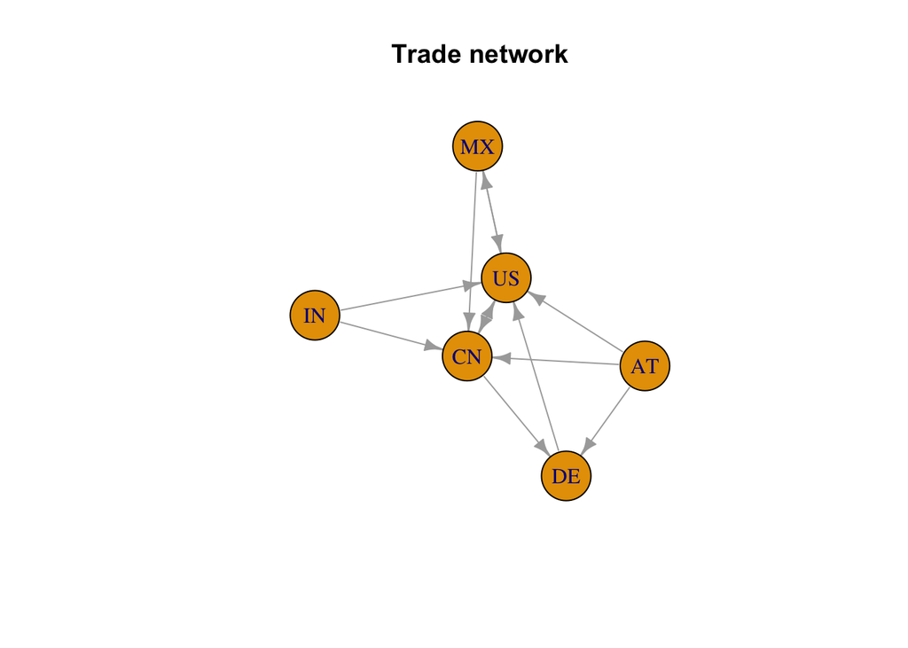

The corresponding adjacency matrix is:

```
##    US MX DE AT CN IN
## US  0  1  0  0  1  0
## MX  1  0  0  0  1  0
## DE  1  0  0  0  0  0
## AT  1  0  1  0  1  0
## CN  1  0  1  0  0  0
## IN  1  0  0  0  1  0
```

2. Who are the most and least central agents in the network? Name, explain, and try to quantify different notions of centrality.

A very basic concept of centrality could define an agent as most central, if it has the highest number of directed edges pointing towards itself (i.e. if it is important export country for most other countries). Using this criterion we can see from the graph that or from columns of adjacency matrix that US the most central agents in this network, because it is top 5 trading partner for all 5 other countries. The least central agents would be Austria and India, since they are not a top 5 export country for any country from this network.

Another basic criterion of centrality could be the amount of outwards pointing arrows of an agent. Thus a country would be considered central if it exports to highest number of countries from this network. In this sense, Germany is least central with only 1 outward arrow, while Austria is most central with 3 outward arrows.

• How would centralities change if you considered a row-normalized network instead?

Germany which had only 1 connection, is the only row with sum of 1. Thus its the only edge which survives row normalization. Thus here depending on criterion US or Germany would be most central agent. Other countries would be all least central.

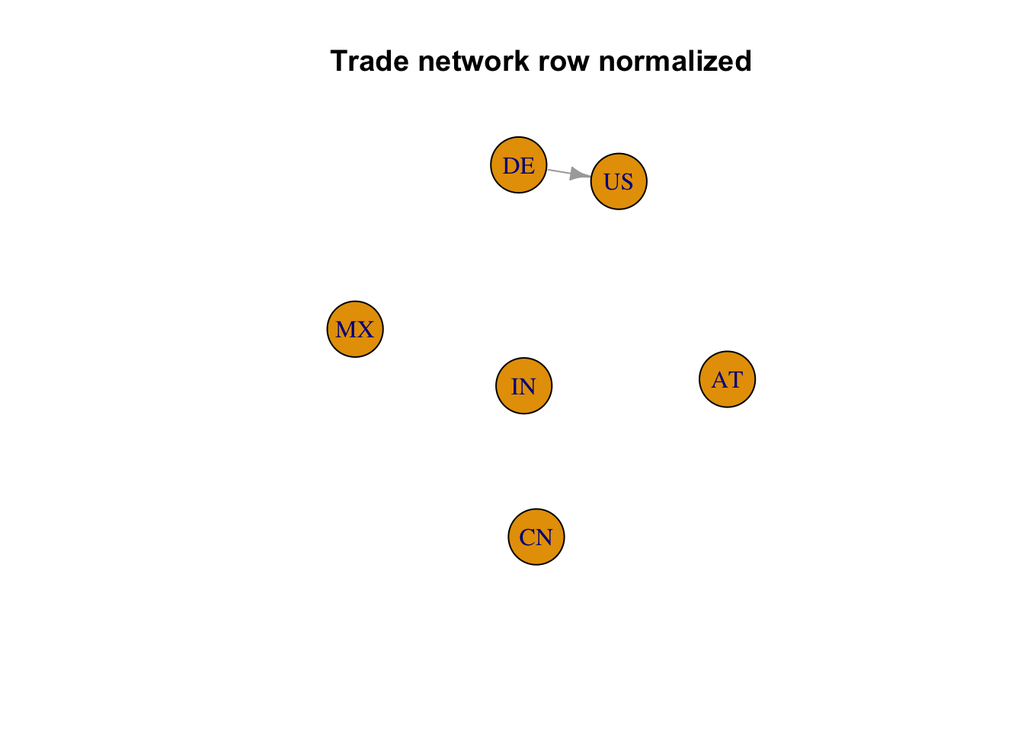

• How would the network change if you removed or added a specific agent? Lets consider the case of removing US:

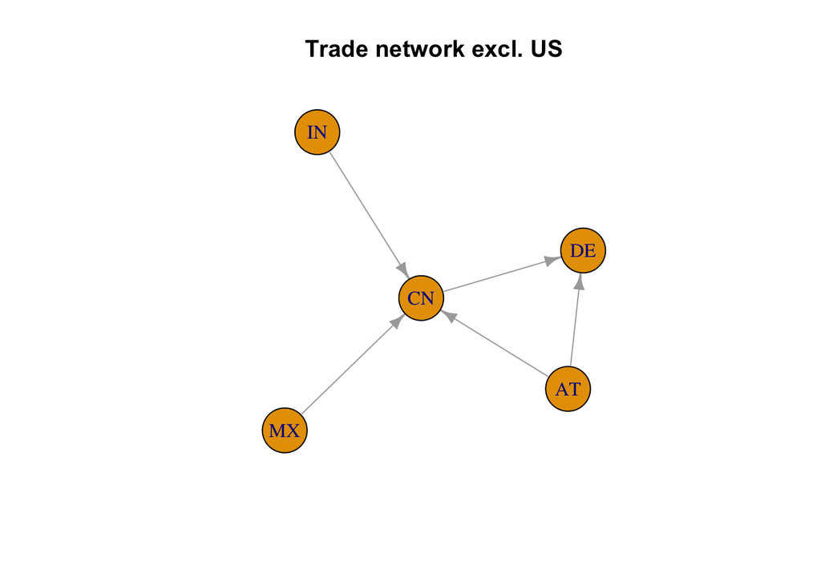

Based on Inflowing arrows, China becomes the most central agent and India, Austria and Mexico the least central agents. Based on Outflowing arrows, Austria is still the most central agent, while Germany is the least central agent.

3.Simulate some agent charaacteristic based on a standard Normal distribution; use this characteristic to simulate responses following a liner-in-means model with your network.

• Repeat this a couple of times, and compare estimates of a standard linear model ($y_{i} = x_{\beta} + \varepsilon_{i}$) with the true values that you used to simulate the data

```r
# number of agents
N = 6

# parameters definition
sigma2 = 1
lambda = 0.6
delta = 0.3
beta = 2 # true beta is 2
W = adj.rn

simulations <- 10000
times <- c(1:simulations)
result <- numeric(simulations)

for (i in times) {

# simulation of vecotrs
x = rnorm(N, 0, 1)
e = rnorm(N, 0, sigma2)

# sampling from reduced form to generate y's

# caluclating means
Wx <- W %*% x

# calculating S
S = diag(N) - lambda * W

# create y's
y = solve(S, Wx * delta + x * beta + e)

model <- lm(y ~ x)

result[i] <- coef(model)["x"]
}

inconsistent_estimate <- mean(result)

my_data <- data.frame(
  Name =  c("Simulated coef", "Real coef"), # Creating a column named ID with values from 1 to 4
  Estimate = c(inconsistent_estimate, beta) # Creating a Name column
)

knitr::kable(my_data, format = "markdown")
```

| Name | Estimate |
| --- | --- |
| Simulated coef | 1.705654 |
| Real coef | 2.000000 |

We simulate the data based on the row normalized adjacency matrix for trade partner connections, that we created in the preceding exercise.

Let’s say we are interested in estimating the impact of a countries fentanyl precursor production (x) on the log of a countries drug deaths (y). Then Wx denotes the average of neighboring countries fentanyl precursor production. We hypothesize that if a countries close trade partners fentanyl precursor production rate is high (as measured by Wx), then the fentanyl related drug deaths are high. Moreover, there are spillover effects with regards to the trading partners fentanyls related deaths from connected countries (Wy).

We specify the following linear-in-means model to estimate the relationship.
$$y = Wy \lambda + Wx \delta + x\beta +
\varepsilon$$

Where $Wy$ denotes the average death rate from drugs of countries that are close neighbors.